# ABM_orchest_hypo

2026-04-02

# Preface

- this document considers one version of LHS and one of GA (100 fixed cycles) – the other with dynamic convergence (convergence_threshold at 0.01) which is designated as **v2**
- Further all of the data displayed below is only considering M (mixed) debates which constitute a mix of pro and anti reduction agents (a future version to be run next week - form 25/5/26 onwards will introduce better segmentation and cross comparison of H and M debates)
- All analyses where data is not labelled in **v1** or **v2** is run with **v1** (which biases the interpretation as each debate is forced to run until it reaches 100 cycles)
- use_distinct_agents: **TRUE** (each agent has the same base parameter value but has a standard deviation associated with each parameter) / **FALSE** (all agents in that debate have the same parameter value -> assumes agents are all the same)

# Global Data Discovery

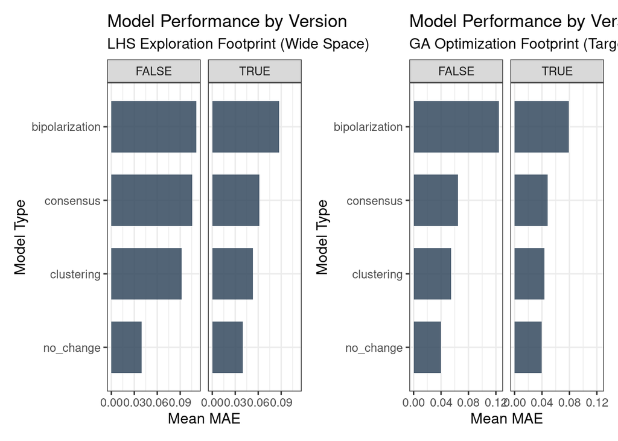

```
## #### Inferential Statistical Progress Testing (Welch's Two-Sample t-Test):
##
##  Welch Two Sample t-test
##
## data:  ga_vector and lhs_vector
## t = -48.962, df = 63394, p-value < 2.2e-16
## alternative hypothesis: true difference in means is not equal to 0
## 95 percent confidence interval:
##  -0.02405216 -0.02220060
## sample estimates:
##  mean of x  mean of y
## 0.06439969 0.08752607
```

```r
if (exists("ga_outputs") && !is.null(ga_outputs$results$comparisons$ranking)) {
  p_lhs <- lhs_outputs$plots$model_performance_rank_main() + labs(subtitle = "LHS Exploration Footprint (Wide Space)")
  p_ga  <- ga_outputs$plots$model_performance_rank_main() + labs(subtitle = "GA Optimization Footprint (Targeted Space)")
  print(p_lhs + p_ga + plot_layout(guides = "collect"))

  cat("#### Inferential Statistical Progress Testing (Welch's Two-Sample t-Test):\n")
  # Map underlying GAMA seed/replicate vector safely
  lhs_vector <- lhs_outputs$inputs$raw$mae
  ga_vector <- ga_outputs$inputs$raw$mae
  print(t.test(ga_vector, lhs_vector, paired = FALSE, alternative = "two.sided"))
}
```

# LHS SENSITIVITY

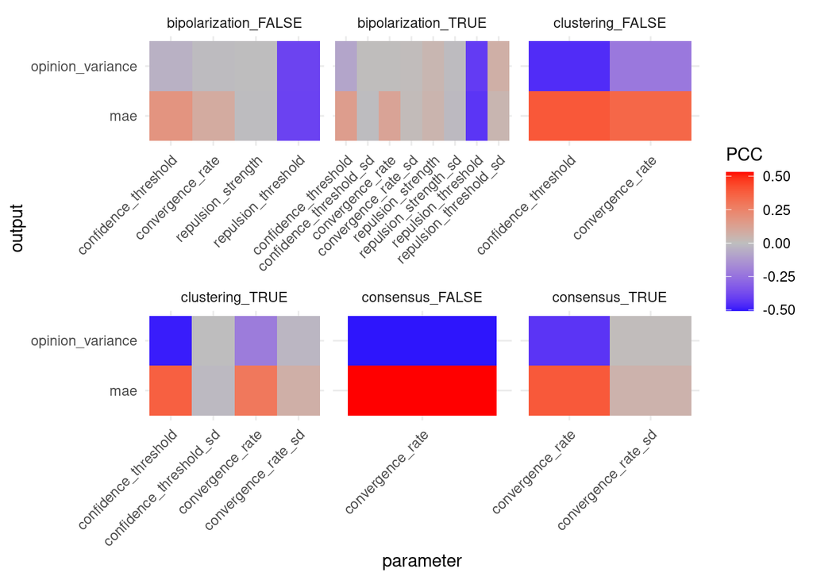

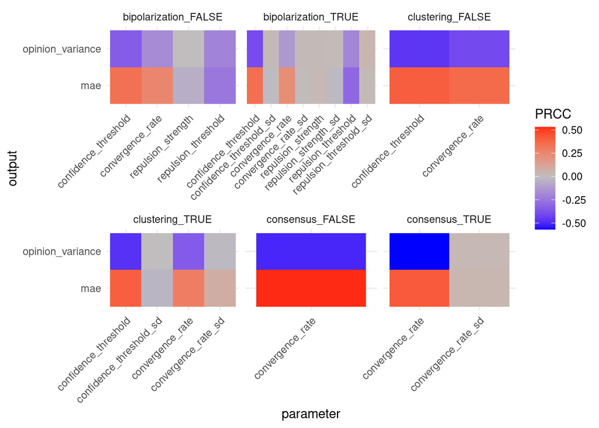

# Debate Level Resolution & Asymmetry

```r
if (!is.null(lhs_outputs$results$comparisons$ranking)) {
  lhs_outputs$results$comparisons$ranking %>%
    mutate(across(where(is.numeric), ~ round(., 4))) %>%
    flextable() %>%
    set_caption("Debate-Specific Performance Rankings (LHS Exploration)") %>%
    autofit()
}
```

Debate-Specific Performance Rankings (LHS Exploration)

| model_type | speaking_mode | mae_mean | mae_sd |
| --- | --- | --- | --- |
| no_change | false | 0.0399 | 0.0140 |
| clustering | true | 0.0528 | 0.0264 |
| consensus | true | 0.0616 | 0.0306 |
| bipolarization | true | 0.0873 | 0.0988 |
| clustering | false | 0.0920 | 0.0436 |
| consensus | false | 0.1058 | 0.0411 |
| bipolarization | false | 0.1112 | 0.1077 |

# Debate-level Valence Accuracy & Asymmetry Gap

## how well the model performs when tracking opposing sides insidie individual debates

```
## #### Interactive Debate Valence Accuracy Profiles
```

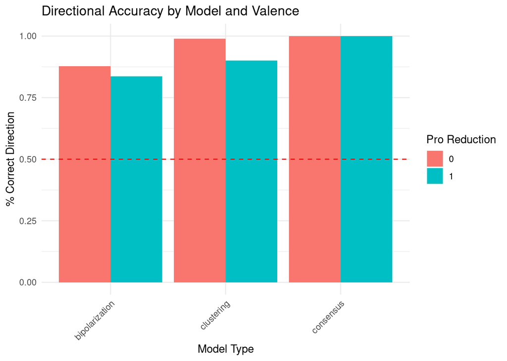

```
## #### Interactive Valence Asymmetry Gap Table
## #### Valence Asymmetry Gap Visualization (System Failure Signature)
```

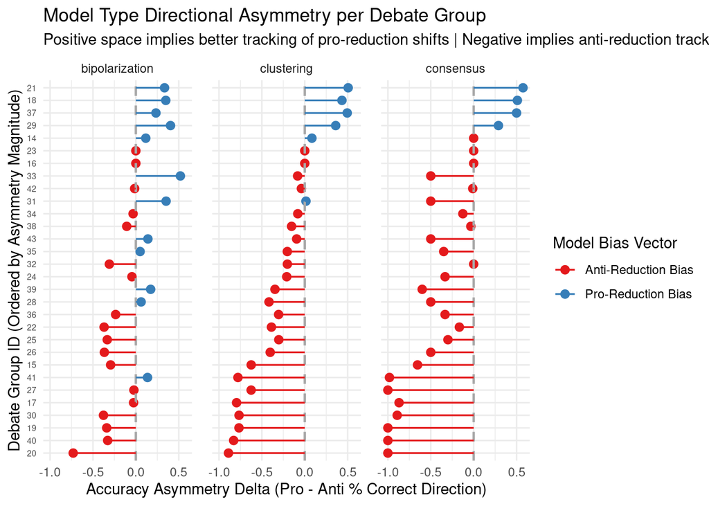

# Interpretation Should confirm that the models track anti-reduction better than pro-reduction. We must: - Lower minimum bound of confidence_threshold -> opens up bounds for dissimilar agents to exchange perspectives - Expand micro-variance SD for confidence_threshold and susceptibility -> might capture real world outliers better - Increase repulsion_strength -> ensure pro-agents polarize cleanly when exposed to opposing arguments

# Micro-agent Analyses

## Tracks how individual agents drift over the course of the debates

```
## #### Hypothesis 1: Pre/Post Attitude Associations (Isolated Replicate Base)
```

| term | estimate | std.error | statistic | p.value |
| --- | --- | --- | --- | --- |
| (Intercept) | 0.04779251 | 0.01495145 | 3.196514 | 0.00170993624166243876616455565908836433663964271545410156250000000000000000000000000 |
| initial_opinion | 0.95486933 | 0.02504488 | 38.126335 | 0.00000000000000000000000000000000000000000000000000000000000000000000000000003928987 |

## Four Quadrants micro-agent drift

```
## #### Four-Quadrant Micro-Agent Drift Direction Scatter
```

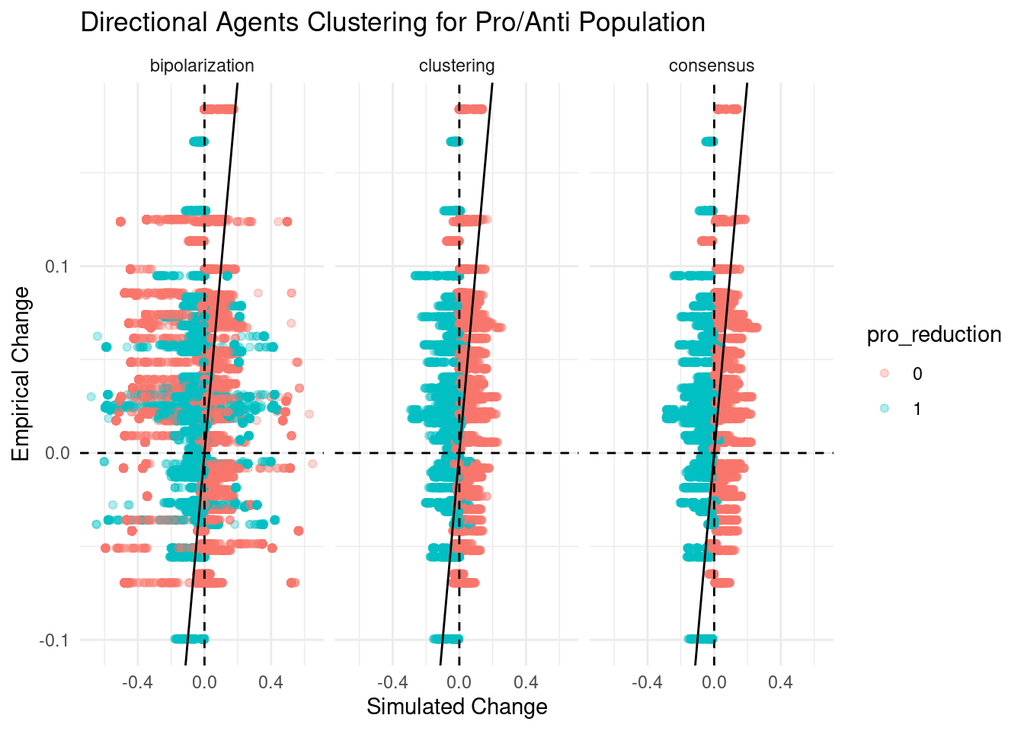

```
## #### Simulated Drift vs Empirical Drift Distributions Across Replicates
```

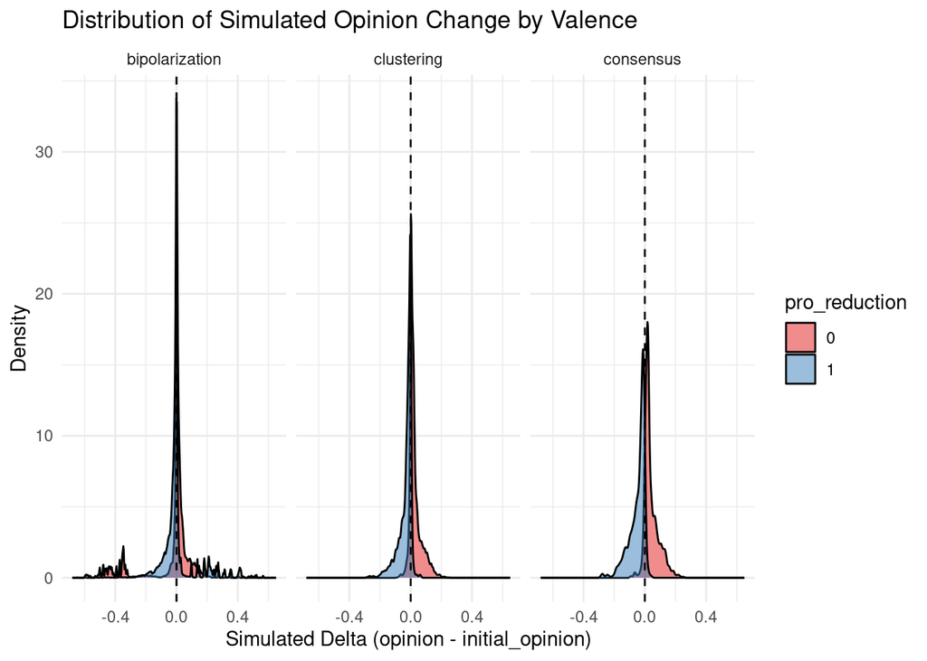

### Interpretation: - should demonstrate that there is a regression to the mean (top left pro-reduction moved further pro empirically - model forces negative change) - bottom right anti-reduction agents (dug in to their opinions - model shifted the positive) - To correct this we should: - lower global convergence_rate -> slows down rate of interaction - compress the lower confidence_threshold bounds -> shrinking interaction width ensure that opinionated agents find counter-arguments entirely incompatible (halting false regression)

## Post-optimization GA Diagnostic Check

```
## ### Optimized GA Valence Asymmetry Gap Evaluation
```

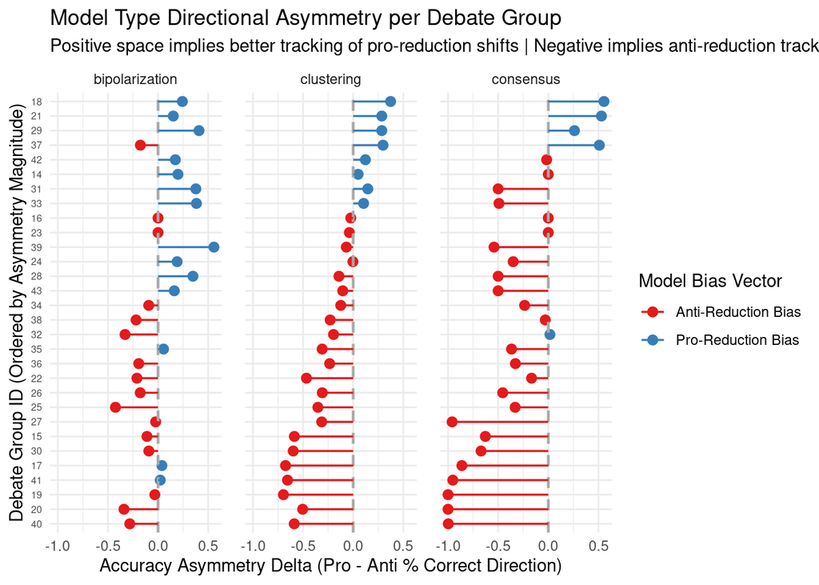

```
## ### Optimized GA Four-Quadrant Replicate Agent Drift
```

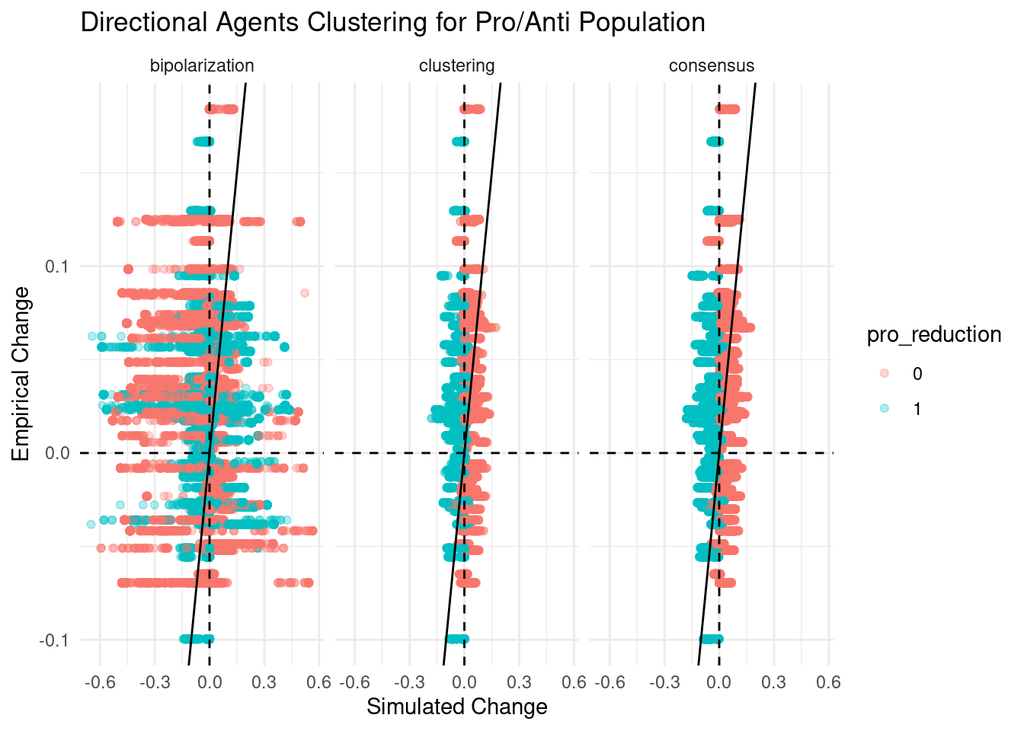